# Notebook

```python
import gzip, os, sys
from IPython.display import HTML
import pandas as pd
import seaborn as sns
import matplotlib.pyplot as plt
import scipy.stats as ss
import scipy as sp
import numpy as np
from collections import defaultdict
from scipy.signal import argrelmin, argrelmax
import math
import matplotlib.patches as patches

#import custom functions for displaying tables, bash commands
sys.path.append(os.path.abspath("/home/damian/"))
from dk_ipython import *
%matplotlib inline
HTML(addToggle())
```

The raw code for this IPython notebook is by default hidden for easier reading. To toggle on/off the raw code, click here.

## Table of contents:

1. Pre-processing: generation of coverage matrices
   1. Trimmomatic
   2. Read mapping
   3. Mark Duplicates
   4. Separate out Smed and Dmel reads
   5. Predict fragment size for single-end Sanchez libraries
   6. Predict fragment size for paired-end Aboobaker libraries
   7. Convert to mid format
   8. Generate bed file with user defined fragment size
   9. Generate matrix (normalized to input)
   10. Calculation of scale factors (both between samples and to Drosophila Spike-in)
   11. Scale Factors used in this paper
2. Plotting ChIP-seq profiles
   1. Load coverage data
   2. Plot distribution of magnitudes and removal of outliers
   3. Conversion to percentage coverage for each profile
   4. Generate Spearman Rank correlations for each epigenetic mark
   5. Generate overall ChIP-seq profiles broken down by FACS category
   6. Generate X2 profiles split by rank
   7. Plots of individual genes
   8. H3K4me3 and H3K27me3 correlational analysis
   9. Pausing Index

For specific questions: anish.dattani@zoo.ox.ac.uk

## 1. Pre-processing: generation of coverage matrices

Chip-seq libraris are available from the Aboobaker lab and Sanchez lab. Both labs used Drosophila spike in controls for down-stream normalization. The Aboobaker lab libraries are pair-end 40bp. The sanchez lab libraries are single-end 50bp. The general steps of this process are:

```
Trim reads for quality
Map reads to the asexual S.mediterranea and D.melanogaster genome
Filter out ambiguous reads (low mapping quality, discordant pairs, PCR duplicates)
Separate out S.med / D.mel reads
Convert to .bed file
Read Trimming
```

#### A. All reads trimmed with trimmomatic:

```
java -jar trimmomatic-0.36.jar PE -threads 32 -phred33 libA libB libA.paired libA.unpaired libB.paired libB.unpaired LEADING:20 TRAILING:20 MINLEN:30 ILLUMINACLIP:/data3/bin/Trimmomatic-0.36/adapters/adapters.fa:2:30:12:1:false TOPHRED33 2> lib.log
```

#### B. Read mapping:

The S.mediterranea asexual genome (SmedAsxl_genome_v1.1.nt) was downloaded from smedgd database (http://smedgd.stowers.org/).

The D. melanogaster genome (r6.10) was downloaded from flybase. The species name (Smed, Dmel) were prepended to each fasta header for easier species identification down-stream. Both fasta files were concatenated and indexed with BWA.

The trimmed reads were mapped to this combined 'smed_dmel.fa' genome index with BWA. The BWA results were piped to samtools for filtering out unmapped reads and mapping quality less than 10:

```
# for single-end reads
bwa mem -t 32 smed_dmel.fasta lib | samtools view -b -F 4 -q 10 - > lib.filtered.bam

# for pair-end reads, use a secondary filter script to filter by pairs.
# discard pairs where both reads have mapping quality less than 10.
# also discard pairs where reads map to separate reference contigs

import sys

pair = []
for line in sys.stdin:
        if line[0] == '@':
                print line.strip()
        else:
                meta = line.strip().split()
                pair.append(meta)

                if len(pair) == 2:
                        if int(pair[0][4]) >= 10 or int(pair[1][4]) >= 10:
                                if pair[0][6] == '=' and pair[1][6] == '=':
                                        print '\t'.join(pair[0])
                                        print '\t'.join(pair[1])

                        pair = []

bwa mem -t 32 smed_dmel.fasta libA.paired libB.paired | samtools view -h -f 2 - | python pe_filterMQ.py | samtools view -b - > lib.filtered.bam
```

The mapping results were sorted with samtools:

```
samtools sort -m 500M -T lib.tmp -O bam -@ 32 lib.filtered.bam > lib.filtered.sorted.bam
```

#### C. Picard tools' MarkDuplicates was used to remove PCR duplicates:

```
java -jar picard.jar MarkDuplicates MAX_FILE_HANDLES=100 INPUT=lib.filtered.sorted.bam OUTPUT=lib.filtered.sorted.markdup.bam METRICS_FILE=lib.filtered.sorted.log REMOVE_DUPLICATES=true
```

#### D. Separate S.mediterranea and D.melanogaster into individual BAM files:

Reads that were mapped to S.mediterranea were extracted from each bam file. Only reads where the forward and reverse both map to the same reference contig were kept. The prepended species name are removed during this step:

```
import sys

for line in sys.stdin:
    if line[0] == '@':
        if line[:3] == '@SQ':
            meta = line.strip().split()
            ref = meta[1].split(':')[1]
            if ref.split('_')[0] != 'dmel':
                meta[1] = 'SN:' + ref.split('_')[1]
                print '\t'.join(meta)
    else:
        meta = line.strip().split('\t')
        if meta[2].split('_')[0] != 'dmel':
            if meta[6] == '=' or meta[6] == '*':
                meta[2] = meta[2].split('_')[1]
                print '\t'.join(meta)

samtools view -h lib.filtered.sorted.markdup.bam | python filterDmel.py | samtools view -b > lib.filtered.sorted.markdup.smed.bam
```

#### E. Predict fragment size on single-end reads:

¶ Sanchez's chip-seq libraries were single-end. Use MACS2's predictd function to predict fragment sizes:

```
macs2 predictd -i file.bam 2> log
```

#### F. Predict fragment size for paired-end libraries:

```
Each BAM file was converted to BED format. The BED file reflects the DNA fragment that was sequenced, not the sequenced read. So for single-end reads, an extension by mean fragment size needs to be performed to get the end coordinate. For pair-end reads, the position from the start of the forward read to the end of the reverse read is recorded in the BED file.

For single-end files, each read was extended from its respective orientation from 5- 3 direction using the estimated fragment size generated previously. The resulting genomic interval is then reported in the BED file. The intervals are bounded by 1 and length of the reference contig in cases where the interval extends beyond the length of the contig or is below 1. For pair-end files, the start of the forward read to the end of the reverse read is designated the fragment interval. Fragment interval lengths that are smaller than the read lengths (meaning the reads are in Reverse-Forward orientation rather than Forward-Reverse) are discarded as ambiguous.

The following script was used to generate the BED file. It requires as input, the BAM file, a size file describing length of each reference contig, and average fragment size.

To get the size file for each reference contig, you can simply run samtools faidx on the genome FASTA file, then run

    cut -f 1,2 genome.fasta.fai > size.file

        to generate the size file.

For single-end files, use the distance predicted previously. For pair-end files, used 0 as the average fragment size to ignore extension. For pair-end data, this script can potentially use up a lot of memory.

import sys
from collections import defaultdict

fragSize = int(sys.argv[1])
refLengths = dict(x.strip().split() for x in open(sys.argv[2]))

if fragSize == 0:
    pairs = defaultdict(list)
    ref = ''
    for line in sys.stdin:
        meta = line.strip().split()

        if meta[2] != ref:
            ref = meta[2]
            pairs = defaultdict(list)

        pairs[meta[0]].append(meta)

        if len(pairs[meta[0]]) == 2:
            a = pairs[meta[0]][0]
            b = pairs[meta[0]][1]

            ref = a[2]
            refLength = int(refLengths[ref])

            aPos = int(a[3])
            aLength = len(a[9])
            aFlag = int(a[1])

            bPos = int(b[3])
            bLength = len(b[9])
            bFlag = int(b[1])

            if aFlag & 16:
                aPos += aLength
            else:
                bPos += bLength

            left = min(aPos,bPos)
            right = max(aPos,bPos)

            left = max(0,left)
            right = min(refLength,right)

            fragLength = right - left

            if fragLength > aLength and fragLength > bLength:
                print '\t'.join([ref,str(left),str(right),meta[0],str(fragLength)])

            del pairs[meta[0]]
else:
    for line in sys.stdin:
        meta = line.strip().split()
        flag = int(meta[1])
        ref = meta[2]
        pos = int(meta[3])
        length = len(meta[9])

        refLength = int(refLengths[ref])

        left = pos
        right = pos + fragSize

        if flag & 16:
            left = pos + length - fragSize
            right = pos + length

        left = max(left,0)
        right = min(refLength,right)

        print '\t'.join([ref,str(left), str(right),meta[0]])
```

run this above script by:

```
samtools view lib.bam | python bam2bed.py fragLength sizes.file > lib.bed
```

#### G. Convert to "mid" format:

Using the fragments .bed file, we also generate a "mid" file where the position of the fragment center is stored. Conceptually, the center of the fragment should be where the protein of interest is bound. In ChIP-seq experimentals, we are really only concerned with point-based data of the binding position. Extending the size of the fragment from the center just smooths out the binding density data.

```
import sys

inFile = open(sys.argv[1],'r')

for line in inFile:
        meta = line.strip().split('\t')
        ref,start,end = meta[:3]
        start = int(start)
        end = int(end)
        mid = start + ((end - start + 1) / 2)

        print ref + '\t' + str(mid)
```

run this above script by:

```
python getMid.py lib.bed | sort -k 1,1 -k2,2n > lib.m
```

#### H. Generate bed file with user defined fragment size

With this "mid" format, we can generate fragment bam/bed formatted data in whatever fragment length we want by using this script to generate a bed file with user defined fragment size:

```
import sys

inFile = open(sys.argv[1],'r')
chrSize = dict([x.strip().split() for x in open(sys.argv[2],'r').read().strip().split('\n')])
fragSize = int(sys.argv[3])

halfSize = fragSize / 2

count = 0
for line in inFile:
        ref, mid = line.strip().split()
        refLength = int(chrSize[ref])
        mid = int(mid)
        start = max(0,mid - halfSize)
        end = min(refLength,mid + halfSize)

        print '\t'.join(map(str,[ref,start,end,'frag' + str(count)]))
        count += 1
```

run this above script by: python mid2fragment.py lib.m chromosomeSizes fragmentSize > lib.fragmentSize.bed

```
bed file can then be optionally converted to bam with the bedtools' bed2bam command.
```

#### I. Generate 2.5kb +/- TSS matrix for ChIP mark

The .bam/.bed file can be used to generate a bedgraph track using bedtools genomecov.

```
./samtools view -b  | genomeCoverageBed -ibam stdin -bga -g SmedAsxl.size.file > chipfile.smed.bdg
```

The resulting .bdg file can be converted to bigwig using UCSC's bedGraphToBigWig:

```
bedGraphToBigWig chipfile.smed.bdg SmedAsxl.size.file chipfile.smed.bw
```

DeepTools' computeMatrix command can be used on multiple bigwig files and the annotations to extract coverage of region around features. Below is an example whereby we produce a matrix describe coverage at 50bp for Input and ChIP sample with respect to the new genome annotation bed file.

```
computeMatrix reference-point -S input.bw chipfile.smed.bw -R ox_smed_asx1.1_1.0.tss.bed -a 2500 -b 2500 -bs 50 -out input.chip.matrix.gz -p max --quiet --missingDataAsZero &
```

#### J. Calculation of normalization factors to apply to the coverage matrix

There are two general types of normalization that can be performed on ChIP-seq data.

```
1. A normalization to input to remove read mappability biases or sequencing biases.
2. A normalization across samples for comparison of regions among samples.
```

There doesn't seem to be a standard way of incorporating both normalization methods to generate one single output track. The strategy for producing the final signal track in this analysis is to subtract the input track from sample track after normalizing coverage across all samples and input.

##### Normalization to input

Normalization to input transforms the sample track in a way to account for biases from mapping, sequencing, and chemistry. To obtain a comparable input track, the sample and input needs to be scaled correctly. Most chip-seq analysis scale sample to input by scaling according to library size. The optimal way would be to the scale by comparing the background in both sample and input. I am going to use the SES method described in this paper: http://www.ncbi.nlm.nih.gov/pmc/articles/PMC3342857/ DeepTool's API was used to calculate the SES scaling factors. For this we need the bam file for the input and ChIP sample. This prints out two scale factors.

```
from deeptools import SES_scaleFactor
python
from deeptools import SES_scaleFactor
result = SES_scaleFactor.estimateScaleFactor(['samplePath','inputPath'],500,200000,1,numberOfProcessors=32)
print str(result['size_factors_SES'][0]) + '\t' + str(result['size_factors_SES'][1])
```

One caveat about input samples. There is anectodal evidence from other bioinformaticians suggesting input libraries might be biased to also include the IP signal. Since input also goes through the cross-linking and sonication process, protein-bound fragments will tend not to be fragmented, potentially resulting in a signal for any protein-bound chromatin. The Sono-seq paper seems to also suggest this:

Mapping accessible chromatin regions using Sono-Seq (http://www.pnas.org/content/106/35/14926.short)

If the signal from input samples are inclusive of the IP signal, then normalization to input will potentially bury real signal.

##### Normalization across samples

Theory behind chip-seq normalization using spike-in samples can be found in this paper: Bin Hu, et al. Biological chromodynamics: a general method for measuring protein occupancy across the genome by calibrating ChIP-seq. Nucl. Acids Res. (2015) doi: 10.1093/nar/gkv670. http://nar.oxfordjournals.org/content/early/2015/06/30/nar.gkv670.full

Cells for each sample were FACS sorted for X1 population and spiked-in with Drosophila S2 cells. Alternatively, following X1 Chromatin preparation and quantification by Qubit, we added a 3% commercially available Drosophile Spike-in (ActiveMotif).

Each sequenced sample contains reads representing occupancy of histone marker on the S.med and D.mel genome:

```
Reads smed = # reads for S.med
Reads dmel = # reads for D.mel
```

For S.med and D.mel, the number of reads is a factor of the number of input cells, the histone occupancy rate, and technical residuals.

```
N = number of cells
O = occupancy rate
R = residuals

Reads = N * O * R
Reads smed = N smed * O smed * R smed
Reads dmel = N dmel * O dmel * R dmel
```

Occupancy is defined as the probability that a position on the genome is bound by the protein of interest. Occupancy rate is the average across all the positions on the genome.

For each sample, the proportion of S.med reads to D.mel reads can be written as:

```
Reads smed / Reads dmel = (N smed * O smed * R smed) / (N dmel * O dmel * R dmel)
```

What we are interested in is the histone occupancy rate of S.med (O smed). The above equation can be rearranged to solve for O smed:

```
O smed = (Reads smed * N dmel * O dmel * R dmel) / (Reads dmel * N smed * R smed)
```

The histone occupancy rate of D.mel (O dmel) is a constant since we are spiking in the same S2 cells in all samples. The residuals (R) include variances from sonication, IP, library prep, sequencing. Residuals do NOT include histone occupancy, which can be different among S.med samples.

```
O dmel * R dmel / R dmel = constant = Alpha
```

Substituting for Alpha in previous equation:

```
O smed = ((Reads smed * N dmel) / (Reads dmel * N smed)) * Alpha
```

Designate ((Reads smed N dmel) / (Reads dmel N smed)) as Scale Factor:

```
Scale Factor = ((Reads smed * N dmel) / (Reads dmel * N smed))

O smed = Scale Factor * Alpha
```

The number of S.med and D.mel cells (N smed and N dmel) mixed in each sample can be obtained by the initial measurement of cell concentration after FACS and spike-in aliquot. Alternatively, we can estimate N smed and N dmel using S.med / D.mel read proportions of our input samples.

According to the paper, this scaling factor is then applied to the density distribution of the coverage (ie. Reads per million). Conversion of raw read coverage to a density distribution can be done by dividing each coverage value per base by the total number of reads, then multiplying by a million. The multiplication by a million make the number bigger and easier to work with.

When putting both RPM conversion and scaling factor together, we are essentially dividing each coverage value per base by:

```
(1e6 / Reads smed) * ((Reads smed * N dmel) / (Reads dmel * N smed))
```

We can get rid of the 1e6 as a constant and take out Reads smed. We are left with:

```
Scaling factor = N dmel / (Reads dmel * N smed)
```

This scaling factor can then be used on the raw read coverage (bedgraph) to normalize samples.

##### Generate comparable coverage tracks among all samples and inputs

We can calculate a scaling for for each sample and its respective input using the SES method. In addition to this, we also calculate a scaling factor among samples using the spike-in method. To consolidate these two scaling factors, we can simply scale all samples according to the spike-in normalization and then scale the respective inputs according to the SES factor while setting the sample to 1.0.

For example:

SES scaling factor:

```
h3k4me3 gfp01 : input gfp01 = 1   : 0.6
h3k4me3 gfp02 : input gfp02 = 1   : 0.4
h3k4me3 lpt01 : input rnai01 = 1   : 0.7
h3k4me3 lpt02 : input rnai02 = 0.8 : 1 or 1 : 1.25
```

Spike-in scaling factor:

```
h3k4me3 gfp01    1
h3k4me3 gfp02    0.6
h3k4me3 rnai01    0.9
h3k4me3 rnai02    0.7
```

Final scaling factor:

```
h3k4me3 gfp01    1
h3k4me3 gfp02    0.6
h3k4me3 rnai01    0.9
h3k4me3 rnai02    0.7

input gfp01    0.6   (1 * 0.6)
input gfp02    0.24  (0.6 * 0.4)
input rnai01    0.63  (0.9 * 0.7)
input rnai02    0.875 (1.25 * 0.7)
```

This final scaling will produce coverage tracks that are comparable among the same IPs.

The following python script was utilized for matrix subtraction:

```
import gzip
import numpy as np
inFile = gzip.open('input.chip.matrix.gz')
inpNorm = scale factor
samNorm = scale factor
inFile.next()
for line in inFile:
    cols = line.strip().replace('nan','0').split('\t')

    data = cols[6:]

    data = map(float,data)

    inputVals = [x * inpNorm for x in data[:100]]

    ChIPVals = [x * samNorm for x in data[100:]]

    norm = [max(0,h3k27Vals[i] - inputVals[i]) for i in range(len(inputVals))]

    print '\t'.join(cols[:6]) + '\t' + '\t'.join(map(str,norm))
```

DeepTools was used to generate a data matrix of profiles based on annotated loci. This matrix file was parsed into data file consisting of coverages for each sample/IP type. This data file represents coverage at each 50bp bin across 5kb region of each loci (2.5k up and downstream of each loci start position).

Underneath we document the plots made in this paper; utilizing the deeptools generated matrix for each ChIP.

#### J. Scale Factors used in this paper and in Mihaylova et. al. (2017) (MLL3/4 Prevents Stem Cell Hyperplasia And Controls Differentiation Programs In A Planarian Cancer Stem Cell Model, BioRxiv)

```
RNA-Seq library         Sample SF       Input SF
aa_x1_h3k4me3_gfp_01    0.88218894621    0.600914311794
aa_x1_h3k4me3_gfp_02    0.95966677872    0.674130090697
aa_x1_h3k4me3_gfp_03    0.552394968171    0.558729702141
aa_x1_h3k4me3_lpt_01    0.915808259834    0.381598670565
aa_x1_h3k4me3_lpt_02    1.0                0.613979197163
aa_x1_h3k4me3_lpt_03    0.452963962102    0.445215653049


aa_x1_h3k4me1_gfp_01    0.96459032622    0.951071177767
aa_x1_h3k4me1_gfp_02    0.929322002571    1.08916554374
aa_x1_h3k4me1_gfp_03    0.353849481684    0.538814176571
aa_x1_h3k4me1_lpt_01    1.0                0.630755202802
aa_x1_h3k4me1_lpt_02    0.7515479874    0.890616388552
aa_x1_h3k4me1_lpt_03    0.385392012257    0.565965518655


aa_x1_h3k27me3_gfp_01    0.670212238126    0.474703809016
aa_x1_h3k27me3_gfp_02    1.0                0.614514716306
aa_x1_h3k27me3_gfp_03    0.348596453072    0.281044204574
aa_x1_h3k27me3_lpt_01    0.720752482921    0.603051423894
aa_x1_h3k27me3_lpt_02    0.733248317316    0.488233050969
aa_x1_h3k27me3_lpt_03    0.397413123449    0.262846984653

aa_x1_k36_01            0.303077006     1.0
aa_x1_k36_02            0.056651272     0.13916828

aa_x1_RNA_Pol_Ser5P_01  6.30521E-05     0.000401732
aa_x1_RNA_Pol_Ser5P_02  0.338095714     1.0
aa_x1_RNA_Pol_Ser5P_03  0.129391907     0.399284173
```

## 2. Plotting profiles

#### A. Load coverage data for H3K4me3, H3K4me1,and H3K27me3, H3K36me3, and RNA Pol II (Ser5P)

```python
prefix = '/home/share/projects/smed_lpt/'
```

```python
#load coverage data for H3K4me3, H3K4me1, and H3K27me3 for AAA GFP and LPT RNAi samples. NB. LPT RNAi Samples pertain to Mihaylova et al (2018) and the same GFP data was used for the analyses in this paper
def smooth(x,window_len=5,window='hanning'):
    if window_len<3:
        return x

    if not window in ['flat', 'hanning', 'hamming', 'bartlett', 'blackman']:
        raise ValueError, "Window is on of 'flat', 'hanning', 'hamming', 'bartlett', 'blackman'"

    s=np.r_[x[window_len-1:0:-1],x,x[-1:-window_len:-1]]
    if window == 'flat':
        w=np.ones(window_len,'d')
    else:
        w=eval('np.'+window+'(window_len)')

    y=np.convolve(w/w.sum(),s,mode='valid')
    return y

def getFC(control,treatment,maxThresh):
    if control == 0 and treatment == 0:
        return 0
    elif control == 0 and treatment > 0:
        return maxThresh
    elif control > 0 and treatment == 0:
        return -maxThresh
    else:
        return min(maxThresh,max(-maxThresh,math.log(treatment / control,2)))

data_gfp = defaultdict(lambda : defaultdict())
data_lpt = defaultdict(lambda : defaultdict())
data_delta = defaultdict(lambda : defaultdict())
data_count = defaultdict(lambda : defaultdict())
data_fc = defaultdict(lambda : defaultdict())

df_data = []

#Following coverage data, append to dataframe max coverage for each locus, log-fold change between GFP and LPT RNAi, max, and min count coverage values
dataFile = open(prefix + 'coverage/aa.data')
lids = []
for line in dataFile:
    lid,mark,gfp,lpt,delta,count = line.strip().split()
    lids.append(lid)
    gfp = smooth(map(float,gfp.split(',')),10)
    lpt = smooth(map(float,lpt.split(',')),10)
    delta = lpt - gfp

    signal_max = max(gfp.max(),lpt.max())
    gfp_norm = [0.0] * 109
    lpt_norm = [0.0] * 109
    delta_norm = [0.0] * 109
    fc = [0.0] * 109
    if signal_max > 0:
        gfp_norm = np.array([x / signal_max for x in gfp])
        lpt_norm = np.array([x / signal_max for x in lpt])
        delta_norm = lpt_norm - gfp_norm
        fc = [getFC(gfp_norm[i],lpt_norm[i],5) if gfp_norm[i] != lpt_norm[i] \
                                  else 0 for i in range(len(gfp_norm))]

    count = map(float,count.split(','))
    count_max = max(count)
    count_min = min(count)
    count_sum = sum(count)
    count_mean = count_sum / float(len(count))

    df_data.append([mark,gfp,lpt,delta,gfp_norm,lpt_norm,delta_norm,fc,count_max,count_min,count_sum,count_mean])

dataFile.close()
df_data = pd.DataFrame(df_data,\
                       columns=['mark','gfp','lpt','delta','gfp_norm',\
                                'lpt_norm','delta_norm','fc','count_max','count_min',\
                                'count_sum','count_mean'],
                       index = lids)
```

```python
#load blast annotations
blastFile = open(prefix + 'genome/ox_smed_asx1.1_1.0.genes.blast.tab')

df_blast = []
for line in blastFile:
    meta = line.strip().split('\t')
    df_blast.append(meta[:3] + [meta[-2]])
df_blast = pd.DataFrame(df_blast,columns=['lid','descr','spe','eval'])
blastFile.close()

blastFile = open(prefix + 'genome/ox_smed_asx1.1_1.0.transdecoder.protein.top10.blast')

df_coding_blast = []
for line in blastFile:
    meta = line.strip().split('\t')
    df_coding_blast.append(meta[:3] + [meta[-2]])
df_coding_blast = pd.DataFrame(df_blast,columns=['lid','descr','spe','eval'])
blastFile.close()
#load categories
all_lids = set(open(prefix + 'figure/all.lids').read().strip().split('\n'))
coding_lids = set(open(prefix + 'figure/coding.lids').read().strip().split('\n'))
tf_lids = set(open(prefix + 'figure/tf.lids').read().strip().split('\n'))
lncrna_lids = set(open(prefix + 'figure/lncrna.lids').read().strip().split('\n'))

propFile = open(prefix + 'figure/facs_proportions.tab')
lids = []
df_props = []
for line in propFile:
    meta = line.strip().split()
    lids.append(meta[0])
    df_props.append(map(float,meta[1:]))

df_props = pd.DataFrame(df_props,index=lids,columns=['x1','x2','xins'])
df_props['x1_2'] = df_props['x1'] + df_props['x2']
df_props['x2_ins'] = df_props['x2'] + df_props['xins']
propFile.close()
x1_lids = set(df_props[df_props['x1'] >= 50.0].index)
x2_lids = set(df_props[df_props['x2'] >= 50.0].index)
xins_lids = set(df_props[df_props['xins'] >= 50.0].index)
x1_2_lids = set(df_props[df_props[['x1','x2']].sum(axis=1) >= 75].index) - x1_lids - x2_lids
x2_ins_lids = set(df_props[df_props[['x2','xins']].sum(axis=1) >= 75].index) - x2_lids - xins_lids
global_lids = set(df_props.index) - x1_lids - x2_lids - xins_lids - x1_2_lids - x2_ins_lids
unclassified_lids = all_lids - x1_lids - x2_lids - xins_lids - x1_2_lids - x2_ins_lids - global_lids
```

```python
#define enriched loci categories

lids_categories = {}
lids_categories['x1'] = x1_lids
lids_categories['x2'] = x2_lids
lids_categories['xins'] = xins_lids
lids_categories['x1_2'] = x1_2_lids
lids_categories['x2_ins'] = x2_ins_lids
lids_categories['x0'] = global_lids
```

```python
def getCellCategory(lid):
    if lid in x1_lids:
        return 'x1'
    elif lid in x2_lids:
        return 'x2'
    elif lid in xins_lids:
        return 'xins'
    elif lid in x1_2_lids:
        return 'x12'
    elif lid in x2_ins_lids:
        return 'x2ins'
    elif lid in global_lids:
        return 'global'
    else:
        return 'unclassified'

def plotProfile(mark,gids,signal,count_thresh,c,ax):
    window = int(math.ceil(5000.0 / 109))
    xticks = range(-2500,2500,window)
    sns.set_style('darkgrid')
    sns.tsplot(list(df_data[(df_data['mark'] == mark) & (df_data['count_max'] >= count_thresh)].ix[gids].dropna()[signal]),\
                   ax=ax,color=c,time=xticks)
```

```python
#Load K36 coverage

chipFile = open('/home/anish/k36.rep12.matrix.gz')

x1_k36 = {}
for line in chipFile:
    try:
        cols = line.strip().split('\t')
        vals = smooth(map(float,cols[6:]),10)
        x1_k36[cols[3]] = vals
    except KeyError:
        pass

chipFile.close()
```

```python
#Produce K36 dataframe with coverage matrix for each locus, FACS proportion for said locus, as well as 'max' coverage value

a = pd.DataFrame(x1_k36)
L = [(k, v) for k, v in x1_k36.items()]
a = pd.DataFrame(L, columns=['','Values'])
u = a.set_index('')
k36_df_props = u.join(df_props)
b = [k for k in all_lids]
df_b = pd.DataFrame(b)
ids = df_b.set_index(0)
a['max'] = pd.DataFrame(k36_df_props['Values'].values.tolist()).max(axis=1)
u = a.set_index('')
k36_df = u.join(df_props)
k36_df_props_max = a.join(df_props)
u = a.set_index('')
k36_df_props_max = u.join(df_props)
```

```python
#Load Pol II Ser5P merged replicate matrix

chipFile = open('/home/anish/RNAPolII.matrix.gz')

x1_ps5 = {}
for line in chipFile:
    try:
        cols = line.strip().split('\t')
        vals = smooth(map(float,cols[6:]),10)
        x1_ps5[cols[3]] = vals
    except KeyError:
        pass

chipFile.close()
```

```python
#Produce Ser5P dataframe with coverage matrix for each locus, FACS proportion for said locus, as well as 'max' coverage value

a_ps5 = pd.DataFrame(x1_ps5)
L_ps5 = [(k, v) for k, v in x1_ps5.items()]
a_ps5 = pd.DataFrame(L_ps5, columns=['','Values'])
u_ps5 = a_ps5.set_index('')
ps5_df_props = u_ps5.join(df_props)
df_b = pd.DataFrame(b)
ids = df_b.set_index(0)
a_ps5['max'] = pd.DataFrame(ps5_df_props['Values'].values.tolist()).max(axis=1)
u_ps5 = a_ps5.set_index('')
ps5_df = u_ps5.join(df_props)
ps5_df_a = a_ps5.join(df_props)
u_ps5 = a_ps5.set_index('')
ps5_df_a = u_ps5.join(df_props)
```

#### B. Plot distribution of magnitudes for for 5 ChIP-seq marks

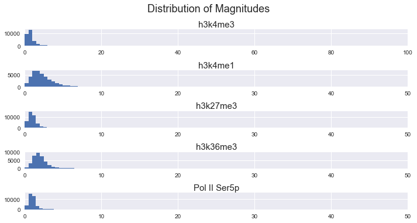

```python
def maxRegion(x):
    #-500 to +800 around tss
    return max(x[44:73])

h3k4me3_gfp_regionMag = pd.Series(df_data[df_data['mark'] == 'h3k4me3']['gfp'].apply(np.max))
h3k4me1_gfp_regionMag = pd.Series(df_data[df_data['mark'] == 'h3k4me1']['gfp'].apply(np.max))
h3k27me3_gfp_regionMag = pd.Series(df_data[df_data['mark'] == 'h3k27me3']['gfp'].apply(np.max))

h3k4me3_lpt_regionMag = pd.Series(df_data[df_data['mark'] == 'h3k4me3']['lpt'].apply(np.max))
h3k4me1_lpt_regionMag = pd.Series(df_data[df_data['mark'] == 'h3k4me1']['lpt'].apply(np.max))
h3k27me3_lpt_regionMag = pd.Series(df_data[df_data['mark'] == 'h3k27me3']['lpt'].apply(np.max))

fig,ax = plt.subplots(5,figsize=[10,5])
h3k4me3_gfp_regionMag[h3k4me3_gfp_regionMag < 100].hist(bins=100,ax=ax[0],alpha=1)
#h3k4me3_gfp_regionMag[h3k4me3_lpt_regionMag < 100].hist(bins=100,ax=ax[0],alpha=0.5)

h3k4me1_gfp_regionMag[h3k4me1_gfp_regionMag < 50].hist(bins=100,ax=ax[1],alpha=1)
#h3k4me1_gfp_regionMag[h3k4me1_lpt_regionMag < 50].hist(bins=100,ax=ax[1],alpha=0.5)

h3k27me3_gfp_regionMag[h3k27me3_gfp_regionMag < 50].hist(bins=100,ax=ax[2],alpha=1)
#h3k27me3_gfp_regionMag[h3k27me3_lpt_regionMag < 50].hist(bins=100,ax=ax[2],alpha=0.5)

df36 = k36_df_props_max[['max']]
df36[df36 < 50].hist(bins=100,ax=ax[3],alpha=1)

dfps5 = ps5_df_a[['max']]
dfps5[dfps5 < 50].hist(bins=100,ax=ax[4],alpha=1)


ax[0].set_title('h3k4me3',fontsize=15)
ax[0].set_xlim(0,100)
ax[1].set_title('h3k4me1',fontsize=15)
ax[1].set_xlim(0,50)
ax[2].set_title('h3k27me3',fontsize=15)
ax[2].set_xlim(0,50)
ax[3].set_title('h3k36me3',fontsize=15)
ax[3].set_xlim(0,50)
ax[4].set_title('Pol II Ser5p',fontsize=15)
ax[4].set_xlim(0,50)
fig.tight_layout()
fig.suptitle('Distribution of Magnitudes',y=1.05,fontsize=18)
fig.tight_layout()
```

```python
#Find RNA Pol II (Ser5P) outliers and remove

ps5_outlier = dfps5[dfps5['max'] > 10].index.tolist()
df=pd.DataFrame(x1_ps5)
x1_ps5df= pd.DataFrame(ps5_df_props)
ps5_df_a.index.name = 'ID'
k36_outlier_new = pd.DataFrame(ps5_outlier)
k36_outlier_new2 = k36_outlier_new.set_index(0)
ps5removeoutlier = ps5_df_props[~ps5_df_props.index.isin(k36_outlier_new.index)]
ps5removeoutlier.index.name = 'ID'
ps5_outlier_removal = u_ps5.loc[~u_ps5.index.isin(ps5_outlier)]
```

```python
k36removeoutlier2 = k36_df_props[k36_df_props.index.isin(ids.index)]
```

```python
#Remove common outliers for 5 ChIP-seq marks


h3k4me3_magOutlier = set(h3k4me3_gfp_regionMag[h3k4me3_gfp_regionMag > 80].index) \
| set(h3k4me3_lpt_regionMag[h3k4me3_lpt_regionMag > 80].index)
h3k4me1_magOutlier = set(h3k4me3_gfp_regionMag[h3k4me1_gfp_regionMag > 20].index) \
| set(h3k4me3_lpt_regionMag[h3k4me1_lpt_regionMag > 20].index)
h3k27me3_magOutlier = set(h3k4me3_gfp_regionMag[h3k27me3_gfp_regionMag > 10].index) \
| set(h3k4me3_lpt_regionMag[h3k27me3_lpt_regionMag > 10].index)
k36_outlier = set(df36[df36['max'] > 10].index.tolist())
ps5_outlier = set(dfps5[dfps5['max'] > 10].index.tolist())

mark_outlier = h3k4me3_magOutlier | h3k4me1_magOutlier | h3k27me3_magOutlier | k36_outlier | ps5_outlier
```

```python
all_lids = set(df_data.index) - mark_outlier
```

#### C. Convert raw coverage of H3K4me3,H3K27me3, H3K4me1, and H3K36me3 to percentage of max coverage following outlier removal

```python
#Following outlier removal, define max for h3k4me3, h3k4me1, and h3k27me3. Turn each locus' coverage matrix into percentage.



h3k4me3_max = max(df_data[df_data['mark'] == 'h3k4me3'].ix[all_lids]['gfp'].apply(np.max).max(), \
                  df_data[df_data['mark'] == 'h3k4me3'].ix[all_lids]['lpt'].apply(np.max).max())
h3k4me1_max = max(df_data[df_data['mark'] == 'h3k4me1'].ix[all_lids]['gfp'].apply(np.max).max(), \
                  df_data[df_data['mark'] == 'h3k4me1'].ix[all_lids]['lpt'].apply(np.max).max())
h3k27me3_max = max(df_data[df_data['mark'] == 'h3k27me3'].ix[all_lids]['gfp'].apply(np.max).max(), \
                  df_data[df_data['mark'] == 'h3k27me3'].ix[all_lids]['lpt'].apply(np.max).max())

def h3k4me3_div(x):
    return [y / h3k4me3_max * 100 for y in x]

def h3k4me1_div(x):
    return [y / h3k4me1_max * 100 for y in x]

def h3k27me3_div(x):
    return [y / h3k27me3_max * 100 for y in x]
```

```python
h3k4me3_gfp = df_data[df_data['mark'] == 'h3k4me3'].ix[all_lids]['gfp'].apply(h3k4me3_div)

h3k4me1_gfp = df_data[df_data['mark'] == 'h3k4me1'].ix[all_lids]['gfp'].apply(h3k4me1_div)

h3k27me3_gfp = df_data[df_data['mark'] == 'h3k27me3'].ix[all_lids]['gfp'].apply(h3k27me3_div)
```

```python
df_data['h3k4me3_perCov'] = df_data[df_data['mark'] == 'h3k4me3'].ix[all_lids]['gfp'].apply(h3k4me3_div)
df_data['h3k4me1_perCov'] = df_data[df_data['mark'] == 'h3k4me1'].ix[all_lids]['gfp'].apply(h3k4me1_div)
df_data['h3k27me3_perCov'] = df_data[df_data['mark'] == 'h3k27me3'].ix[all_lids]['gfp'].apply(h3k27me3_div)
```

```python
#Following outlier removal, define max for h3k36me3

df=pd.DataFrame(x1_k36)
k36df= pd.DataFrame(k36_df_props)
k36df.index.name = 'ID'
k36_outlier_new = pd.DataFrame(k36_max)
k36_outlier_new2 = k36_outlier_new.set_index(0)
k36removeoutlier = k36_df_props[~k36_df_props.index.isin(k36_outlier_new.index)]
k36_outlier_new.index.name = 'ID'
k36_outlier_removal = u.loc[~u.index.isin(k36_outlier)]
K36_outlierremove_array = k36_outlier_removal.Values
k36_df = pd.DataFrame(k36_outlier_removal['max'])
k36_df[k36_df['max']==k36_df['max'].max()]
```

|  | max |
| --- | --- |
| asx1.1_ox1.0.loc.16205 | 9.998535 |

```python
#Convert h3k36me3 coverage to percentage

k36_gfp = K36_outlierremove_array.apply(lambda x : [(y/9.99854)*100 for y in x])
```

```python
# define max for RNA Pol II Ser5P

ps5_df = pd.DataFrame(ps5_outlier_removal['max'])
ps5_df[ps5_df['max']==ps5_df['max'].max()]
```

| ID | max |
| --- | --- |
| asx1.1_ox1.0.loc.31600 | 9.974214 |

```python
#Convert RNA Pol II Ser5P coverage to percentage

ps5_perc = ps5_outlier_removal.Values.apply(lambda x : [(y/9.97421)*100 for y in x])
```

#### D. Spearman Rank profiles of four ChIP-seq marks and FACS proportion

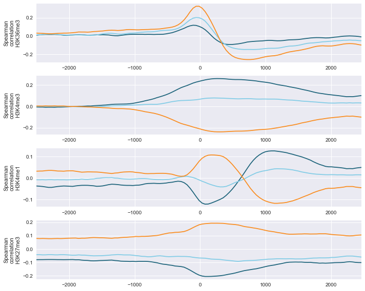

```python
def getPropCorr2(pop):
    df2 = k36_df_props_max[(k36_df_props_max['max'] >= 3)]
    l2 = len(df2['Values'][0])
    c2 = [ss.spearmanr([x2[i] for x2 in df2['Values']],df2[pop]) for i in range(l2)]
    return c2

def getPropCorr(mark,pop,countThresh=10):
    df = pd.DataFrame(df_data[(df_data['mark'] == mark) & (df_data['count_max'] >= countThresh)]\
                      ['gfp']).join(df_props,how='inner')
    l = len(df['gfp'][0])
    c = [ss.spearmanr([x[i] for x in df['gfp']],df[pop]) for i in range(l)]
    return c

window = int(math.ceil(5000.0 / 109))
idx = range(-2500,2500,window)
fig,ax = plt.subplots(4,figsize=[10,8])
colors=['#1C637A','#81CCE6','#FA8D20','#4AB545']

pd.Series([x2[0] for x2 in getPropCorr2('x1')],index=idx).plot(ax=ax[0],color=colors[0])
pd.Series([x2[0] for x2 in getPropCorr2('x2')],index=idx).plot(ax=ax[0],color=colors[1])
pd.Series([x2[0] for x2 in getPropCorr2('xins')],index=idx).plot(ax=ax[0],color=colors[2])

pd.Series([x[0] for x in getPropCorr('h3k4me3','x1',3)],index=idx).plot(ax=ax[1],color=colors[0])
pd.Series([x[0] for x in getPropCorr('h3k4me3','x2',3)],index=idx).plot(ax=ax[1],color=colors[1])
pd.Series([x[0] for x in getPropCorr('h3k4me3','xins',3)],index=idx).plot(ax=ax[1],color=colors[2])

pd.Series([x[0] for x in getPropCorr('h3k4me1','x1',3)],index=idx).plot(ax=ax[2],color=colors[0])
pd.Series([x[0] for x in getPropCorr('h3k4me1','x2',3)],index=idx).plot(ax=ax[2],color=colors[1])
pd.Series([x[0] for x in getPropCorr('h3k4me1','xins',3)],index=idx).plot(ax=ax[2],color=colors[2])

pd.Series([x[0] for x in getPropCorr('h3k27me3','x1',3)],index=idx).plot(ax=ax[3],color=colors[0])
pd.Series([x[0] for x in getPropCorr('h3k27me3','x2',3)],index=idx).plot(ax=ax[3],color=colors[1])
pd.Series([x[0] for x in getPropCorr('h3k27me3','xins',3)],index=idx).plot(ax=ax[3],color=colors[2])

ax[0].set_ylabel('Spearman\ncorrelation\nH3K36me3')
ax[1].set_ylabel('Spearman\ncorrelation\nH3K4me3')
ax[2].set_ylabel('Spearman\ncorrelation\nH3K4me1')
ax[3].set_ylabel('Spearman\ncorrelation\nH3K27me3')


fig.tight_layout()
```

#### E. Overall gene ChIP-seq profiles minus outliers

```python
# list of X1,X2,Xins minus common outliers
x1_minus_outlier = (x1_lids - mark_outlier)
x2_minus_outlier = (x2_lids - mark_outlier)
xins_minus_outlier = (xins_lids - mark_outlier)
```

```python
#k4me3,k4me1,k27me3 overall gene profiles, for all genes following the removal of outliers
def plotProfile(mark,gids,signal,count_thresh,c,ax):
    window = int(math.ceil(5000.0 / 109))
    xticks = range(-2500,2500,window)

    sns.tsplot(list(df_data[(df_data['mark'] == mark) & \
                            (df_data['count_max'] >= count_thresh)].ix[gids].dropna()[signal]),\
                   ax=ax,color=c,time=xticks)

def plotProfileGroups(groups,leg,signal='_perCov',colors=['#1C637A','#81CCE6','#FA8D20','#4AB545']):
    fig, ax = plt.subplots(3,figsize=[10,8])


    for i,group in enumerate(groups):
        plotProfile('h3k4me3',group,'gfp' + signal,0,colors[i],ax[0])

    for i,group in enumerate(groups):
        plotProfile('h3k27me3',group,'gfp' + signal,0,colors[i],ax[1])

    for i,group in enumerate(groups):
        plotProfile('h3k4me1',group,'gfp' + signal,0,colors[i],ax[2])

    ax[0].set_ylabel('H3K4me3',fontsize=20)
    ax[1].set_ylabel('H3K27me3',fontsize=20)
    ax[2].set_ylabel('H3K4me1',fontsize=20)
    ax[0].legend(leg)
    ax[1].legend(leg)
    ax[2].legend(leg)
```

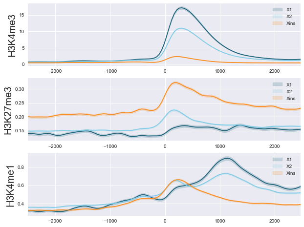

```python
plotProfileGroups([x1_lids - mark_outlier,\
                   x2_lids - mark_outlier,\
                   xins_lids - mark_outlier]\
                  ,['X1','X2','Xins'],signal='')
```

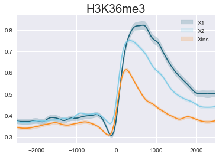

```python
# k36me3 overall gene profiles, for all genes following the removal of outliers


x1_lids_n1 = []
for k in x1_minus_outlier:
    try:
        x1_lids_n1.append(x1_k36[k])
    except KeyError:
        pass
x2_lids_n1 = []
for k in x2_minus_outlier:
    try:
        x2_lids_n1.append(x1_k36[k])
    except KeyError:
        pass
xins_lids_n1 = []
for k in xins_minus_outlier:
    try:
        xins_lids_n1.append(x1_k36[k])
    except KeyError:
        pass

window = int(math.ceil(5000.0 / 109))
xticks = range(-2500,2500,window)

sns.tsplot((x1_lids_n1),time=xticks,color="#1C637A")
sns.tsplot((x2_lids_n1),time=xticks,color="#81CCE6")
sns.tsplot((xins_lids_n1),time=xticks,color="#FA8D20")
plt.legend(['X1','X2','Xins'])
plt.title('H3K36me3',fontsize=20)
```

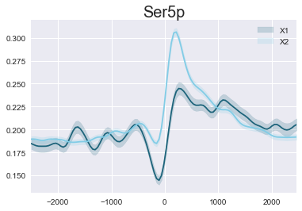

```python
# RNA Pol II Ser5p overall gene profiles, for all genes following the removal of outliers


x1_lids_n2 = []
for k in x1_minus_outlier:
    try:
        x1_lids_n2.append(x1_ps5[k])
    except KeyError:
        pass
x2_lids_n2 = []
for k in x2_minus_outlier:
    try:
        x2_lids_n2.append(x1_ps5[k])
    except KeyError:
        pass
xins_lids_n2 = []
for k in xins_minus_outlier:
    try:
        xins_lids_n2.append(x1_ps5[k])
    except KeyError:
        pass

window = int(math.ceil(5000.0 / 109))
xticks = range(-2500,2500,window)

sns.tsplot((x1_lids_n2),time=xticks,color="#1C637A")
sns.tsplot((x2_lids_n2),time=xticks,color="#81CCE6")
plt.legend(['X1','X2','Xins'])
plt.title('Ser5p',fontsize=20)
```

#### F. X2 rank profiles of ChIP-seq marks

```python
# Produce DFs with appended FACS categorizations for each mark following outlier removal. The IDs per ChIP X2 plot given common outlier removal

ak4me1 = pd.DataFrame(h3k4me1_gfp)
k4me1_minusoutlier = ak4me1.join(df_props)
ak4me3 = pd.DataFrame(h3k4me3_gfp)
k4me3_minusoutlier = ak4me3.join(df_props)
ak27me3 = pd.DataFrame(h3k27me3_gfp)
k27me3_minusoutlier = ak27me3.join(df_props)
```

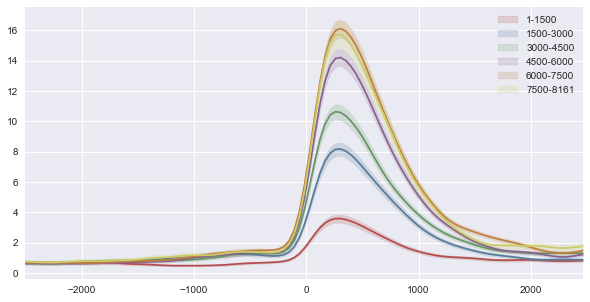

```python
#h3k4me3


x_k4me3 = k4me3_minusoutlier[k4me3_minusoutlier['x2'] > 50]['x2']
x_k4me3 = x_k4me3.sort_values(ascending=False)
fig,ax = plt.subplots(figsize=[10,5])
c = sns.color_palette("Set1", n_colors=9, desat=.5)

for n,i in enumerate(range(0,len(x_k4me3), 1500)):
    gids = x_k4me3[i:i+1500].index
    plotProfile('h3k4me3',gids,'gfp',0,c[n],ax)
    plt.legend(['1-1500','1500-3000','3000-4500','4500-6000','6000-7500','7500-8161'])
    sns.set_style('darkgrid')
```

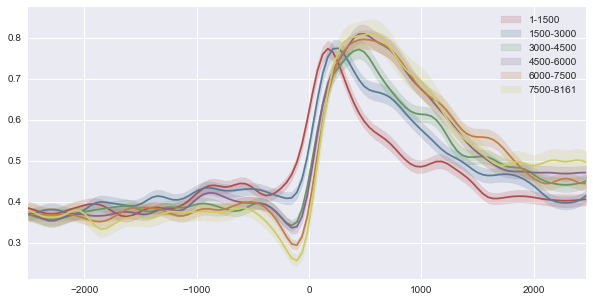

```python
#h3k36me3


window = int(math.ceil(5000.0 / 109))
xticks = range(-2500,2500,window)

k36_new = k4me3_minusoutlier[k4me3_minusoutlier['x2'] > 50]['x2']
k36_new = k36_new.sort_values(ascending=False)
fig,ax = plt.subplots(figsize=[10,5])
c = sns.color_palette("Set1", n_colors=9, desat=.5)
sns.set_style('darkgrid')

for n,i in enumerate(range(0,len(k36_new), 1500)):
    gids = k36_new[i:i+1500].index
    sns.tsplot([K36_outlierremove_array[k] for k in gids],time=xticks,color=c[n])
    sns.set_style('darkgrid')


    plt.legend(['1-1500','1500-3000','3000-4500','4500-6000','6000-7500','7500-8161'])
```

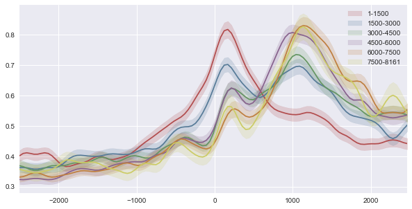

```python
#h3k4me1

k4me1 = k4me1_minusoutlier[k4me1_minusoutlier['x2'] > 50]['x2']
k4me1 = k4me1.sort_values(ascending=False)
fig,ax = plt.subplots(figsize=[10,5])
c = sns.color_palette("Set1", n_colors=9, desat=.5)
for n,i in enumerate(range(0,len(k4me1),1500)):
    gids = k4me1[i:i+1500].index - mark_outlier
    plotProfile('h3k4me1',gids,'gfp',0,c[n],ax)
    plt.legend(['1-1500','1500-3000','3000-4500','4500-6000','6000-7500','7500-8161'])
```

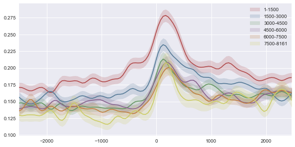

```python
#h3k27me3

x_k27me3 = k27me3_minusoutlier[k27me3_minusoutlier['x2'] > 50]['x2']
x_k27me3 = x_k27me3.sort_values(ascending=False)
fig,ax = plt.subplots(figsize=[10,5])
c = sns.color_palette("Set1", n_colors=9, desat=.5)

for n,i in enumerate(range(0,len(x_k27me3), 1500)):
    gids = x_k27me3[i:i+1500].index
    plotProfile('h3k27me3',gids,'gfp',0,c[n],ax)
    plt.legend(['1-1500','1500-3000','3000-4500','4500-6000','6000-7500','7500-8161'])
```

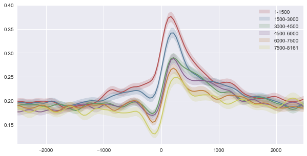

```python
#RNA pol II Ser5p


window = int(math.ceil(5000.0 / 109))
xticks = range(-2500,2500,window)

x1_ps5_new = k4me3_minusoutlier[k4me3_minusoutlier['x2'] > 50]['x2']
x1_ps5_new = x1_ps5_new.sort_values(ascending=False)
fig,ax = plt.subplots(figsize=[10,5])
c = sns.color_palette("Set1", n_colors=9, desat=.5)
sns.set_style('darkgrid')

for n,i in enumerate(range(0,len(x1_ps5_new), 1500)):
    gids = x1_ps5_new[i:i+1500].index
    sns.tsplot([x1_ps5[k] for k in gids],time=xticks,color=c[n])
    sns.set_style('darkgrid')


    plt.legend(['1-1500','1500-3000','3000-4500','4500-6000','6000-7500','7500-8161'])
```

#### G. Individual gene profiles of ChIP-seq marks for X1 genes (example)

Underneath is an example plot for X1 genes for all tracks, 2.5KB either side of the TSS. For publication, owing to constraints on figure size, plots were trimmed manually.

```python
#Plot genes with the same axis according to the maximum value.



def plotExp4(tid, title, ax):
    sns.set(font_scale = 1)
    sns.set_style("white")
    sns.set_style("ticks")
    sns.despine()


    window = int(math.ceil(5000.0 / 109))
    xticks = range(-2500,2500,window)

    pd.Series(h3k4me3_gfp.ix[tid],index=xticks).plot(kind='area',color='#0B5394',ax=ax[0],fontsize=40)
    pd.Series(k36_gfp.ix[tid],index=xticks).plot(kind='area',ax=ax[1], color='#9e45b5',fontsize=40)
    pd.Series(h3k27me3_gfp.ix[tid],index=xticks).plot(kind='area',ax=ax[2], color='#14a507',fontsize=40)
    pd.Series(h3k4me1_gfp.ix[tid],index=xticks).plot(kind='area',ax=ax[3], color='red',fontsize=40)

    maxy = max(max(h3k4me3_gfp.ix[tid]),max(k36_gfp.ix[tid]),max(h3k27me3_gfp.ix[tid]),max(h3k4me1_gfp.ix[tid]))
    ax[0].set_ylim(0,maxy)
    ax[1].set_ylim(0,maxy)
    ax[2].set_ylim(0,maxy)
    ax[3].set_ylim(0,maxy)

    ax[0].xaxis.set_ticklabels([])
    ax[1].xaxis.set_ticklabels([xticks])
    ax[2].xaxis.set_ticklabels([xticks])
    ax[3].xaxis.set_ticklabels([xticks])


    ax[0].set_title(title,fontsize=25)


def plotExamples4(e,w,h):
    n = int(round(float(len(e)) / 2))
    rows = n * 4
    cols = 2

    fig, ax = plt.subplots(rows,cols,figsize=[w,h])
    fig.subplots_adjust(hspace=0)

    s = 0
    for item in e[:n]:
        axes = [ax[s,0], ax[s + 1,0], ax[s + 2,0],ax[s + 3,0]]
        plotExp4(item[0],item[1],axes)
        s += 4

    s = 0
    for item in e[n:]:
        axes = [ax[s,1], ax[s + 1,1], ax[s + 2,1],ax[s + 3,1]]
        plotExp4(item[0],item[1],axes)
        s += 4

    fig.tight_layout()
```

```python
#example X1 gene profiles

x1newExamples = [x.split('\t') for x in '''asx1.1_ox1.0.loc.31395	Smed-piwi1
asx1.1_ox1.0.loc.09397	Smed-Cyclin-B1
asx1.1_ox1.0.loc.03346	ercc6
asx1.1_ox1.0.loc.01393	Smed-ddx52
asx1.1_ox1.0.loc.00709	Smed-cdt1
asx1.1_ox1.0.loc.09127	Smed-wee1
asx1.1_ox1.0.loc.36387	Smed-tonsoku
asx1.1_ox1.0.loc.13409	Smed-cytokenisis
asx1.1_ox1.0.loc.00891	Smed-ddx24
asx1.1_ox1.0.loc.19362	Smed-exonuclease
asx1.1_ox1.0.loc.10088	Smed-setd8
asx1.1_ox1.0.loc.08008	Smed-mcm2'''.split('\n')]
```

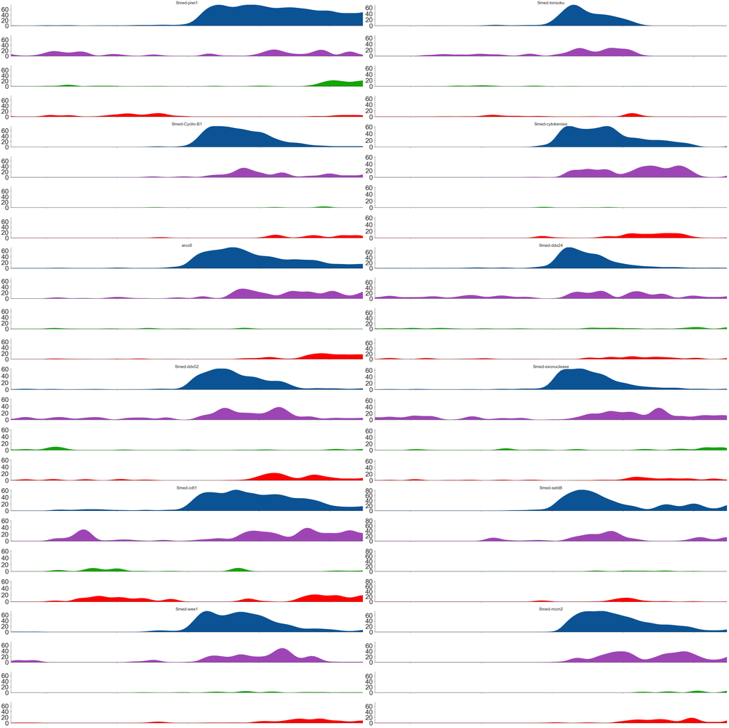

```python
plotExamples4(x1newExamples,60,60)
```

### H. Correlational analysis between H3K4me3 and H3K27me3

```python
#Order ID categoires from high to low FACS rank category for each enrichment group


x1_lid_order = [x for x in df_props['x1'].sort_values(ascending=False).index \
                if x not in mark_outlier and x in set(x1_lids)]
x2_lid_order = [x for x in df_props['x2'].sort_values(ascending=False).index \
                if x not in mark_outlier and x in set(x2_lids)]
xins_lid_order = [x for x in df_props['xins'].sort_values(ascending=False).index \
                if x not in mark_outlier and x in set(xins_lids)]
x2ins_lids = set(df_props[df_props[['x2','xins']].sum(axis=1) >= 75].index) - x2_lids - xins_lids
```

```python
#Load mex-3 differential list following Kallist and Sleuth analysis to current genome


mexFile = open('/home/share/projects/smed_lpt/whole_mex3/results.final.tab')
mexFile.next()
fc = []
lids = []
mex3_rnai = []
for line in mexFile:
    meta = line.strip().split()
    if meta[4] != 'NA':
        if float(meta[4]) <= 0.05:
            lids.append(meta[0])
            fc.append(float(meta[3]))
mex3_rnai = pd.Series(fc,index=lids)
mexFile.close()
```

```python
#count number of IDS with -1 log2 fold change (i.e. fc of -2 or less)

mex3_down_lids = mex3_rnai[mex3_rnai <= -1].index
len(mex3_down_lids)
```

```
285
```

```python
#count number of IDS in X2_Xins category (x2+xins FACS proportion => 75%) with <= 10% proportion in X1


x2_xins_10x1 = pd.DataFrame([df_props.ix[x2ins_lids][df_props['x1'] <= 10].index])
len(x2_xins_10x1.columns)
```

```
370
```

[figure not shown]

```python
fig,ax = plt.subplots(3,2,figsize=[10,10])

window = int(math.ceil(5000.0 / 109))
xticks = range(-2500,2500,window)

sns.tsplot(list(df_data[df_data['mark'] == 'h3k4me3']['h3k4me3_perCov']\
                .ix[x1_lid_order[:1000]].dropna()),time=xticks,ax=ax[0][0],color='#0B5394')
sns.tsplot(list(df_data[df_data['mark'] == 'h3k27me3']['h3k27me3_perCov']\
                .ix[x1_lid_order[:1000]].dropna()),time=xticks,ax=ax[0][0],color='#4AB545')


sns.tsplot(list(df_data[df_data['mark'] == 'h3k4me3']['h3k4me3_perCov']\
                .ix[x2_lid_order[:1000]].dropna()),time=xticks,ax=ax[1][0],color='#0B5394')
sns.tsplot(list(df_data[df_data['mark'] == 'h3k27me3']['h3k27me3_perCov']\
                .ix[x2_lid_order[:1000]].dropna()),time=xticks,ax=ax[1][0],color='#4AB545')

sns.tsplot(list(df_data[df_data['mark'] == 'h3k4me3']['h3k4me3_perCov']\
                .ix[xins_lid_order[:1000]].dropna()),time=xticks,ax=ax[0][1],color='#0B5394')
sns.tsplot(list(df_data[df_data['mark'] == 'h3k27me3']['h3k27me3_perCov']\
                .ix[xins_lid_order[:1000]].dropna()),time=xticks,ax=ax[0][1],color='#4AB545')

sns.tsplot(list(df_data[df_data['mark'] == 'h3k4me3']['h3k4me3_perCov']\
                .ix[mex3_down_lids[:285]].dropna()),time=xticks,ax=ax[1][1],color='#0B5394')
sns.tsplot(list(df_data[df_data['mark'] == 'h3k27me3']['h3k27me3_perCov']\
                .ix[mex3_down_lids[:285]].dropna()),time=xticks,ax=ax[1][1],color='#4AB545')

sns.tsplot(list(df_data[df_data['mark'] == 'h3k4me3']['h3k4me3_perCov']\
                .ix[df_props.ix[x2ins_lids][df_props['x1'] <= 10].index].dropna())\
           ,time=xticks,ax=ax[2][1],color='#0B5394')
sns.tsplot(list(df_data[df_data['mark'] == 'h3k27me3']['h3k27me3_perCov']\
                .ix[df_props.ix[x2ins_lids][df_props['x1'] <= 10].index].dropna())\
           ,time=xticks,ax=ax[2][1],color='#4AB545')


ax[0][0].set_title('top 1000 ranked X1 loci')
ax[0][1].set_title('top 1000 ranked Xins loci')
ax[1][0].set_title('top 1000 ranked X2 loci')
ax[1][1].set_title('top 1000 ranked smed-Mex3 RNAi\n(pvalue <=0.05, fc <= 2) loci')
ax[2][1].set_title('X2/Xins loci with <= 10% Xins expression')


fig.tight_layout()
```

```python
bivalence_gfp = pd.concat([h3k4me3_gfp,h3k27me3_gfp],axis=1)
bivalence_gfp.columns = ['h3k4me3','h3k27me3']
```

```python
#calculate correlation between h3k4me3 and h3k27me3 values between -1kb and 1.5kb upstream of TSS

bivalence_corr = []
for index, row in bivalence_gfp.iterrows():
    if sum(row[0]) > 0 and sum(row[1]) > 0:
        bivalence_corr.append([index,ss.pearsonr(row[0][30:80],row[1][30:80])[0]])
```

```python
bivalence_corr = pd.Series([x[1] for x in bivalence_corr],index=[x[0] for x in bivalence_corr])
```

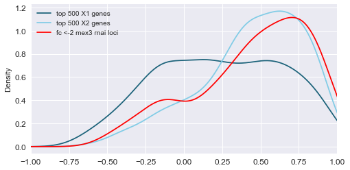

```python
x1_ranking_minus_outlier = k4me3_minusoutlier[k4me3_minusoutlier['x1'] > 50]['x1']
x1_500_minus_outlier = x1_ranking_minus_outlier.sort_values(ascending=False)
x2_ranking_minus_outlier = k4me3_minusoutlier[k4me3_minusoutlier['x2'] > 50]['x2']
x2_500_minus_outlier = x2_ranking_minus_outlier.sort_values(ascending=False)

x1_500_minus_outlier_2 = set(x1_500_minus_outlier.index[:500])
x2_500_minus_outlier_2 = set(x2_500_minus_outlier.index[:500])

fig,ax = plt.subplots(figsize=[8,4])
ax.set_xlim(-1,1)
bivalence_corr.ix[x1_500_minus_outlier_2].plot(kind='kde',ax=ax,color='#1C637A',fontsize=12)
bivalence_corr.ix[x2_500_minus_outlier_2].plot(kind='kde',ax=ax,color='#81CCE6')
bivalence_corr.ix[mex3_down_lids].plot(kind='kde',ax=ax,color='red')
plt.savefig('/home/anish/corr.svg')
plt.legend(['top 500 X1 genes','top 500 X2 genes','fc <-2 mex3 rnai loci'])
```

### I. Pausing Index

```
import gzip
import numpy as np
import csv

with gzip.open('/home/anish/RNAPolII.matrix.gz') as infile:
    for line in infile:
        cols = line.strip().replace('nan','0').split('\t')
        row = cols[6:]

        first3, last = row[40:60], row[60:100]
        try:
                average = sum(map(float, first3)) / sum(map(float, last))
        except ZeroDivisionError:
                average = 0
        print average
```